# Coursera Statistical Inference Project 2

Lisa Yuan

January 28, 2016

## Overview

In this analysis I explored ToothGrowth dataset about “the Effect of Vatamin C on Tooth Growth in Guinea Pigs”. I used statistical hypothesis tests to compare tooth length by summpliment type and does in miligrams.

The ToothGrowth dataset is in R library datasets. It contains 60 observations on 3 variables.

1. len: Length of odontoblasts
2. supp: Supplement type (VC or OJ)
3. dose: Dose in milligrams/day

```r
### load datasets and ggplot2 libraries
library(datasets)
library(ggplot2)

### load the ToothGrowth dataset
data("ToothGrowth")

### Review the first 6 observations
head(ToothGrowth)
```

```
##    len supp dose
## 1  4.2   VC  0.5
## 2 11.5   VC  0.5
## 3  7.3   VC  0.5
## 4  5.8   VC  0.5
## 5  6.4   VC  0.5
## 6 10.0   VC  0.5
```

```r
### Review the structure of the data
str(ToothGrowth)
```

```
## 'data.frame':    60 obs. of  3 variables:
##  $ len : num  4.2 11.5 7.3 5.8 6.4 10 11.2 11.2 5.2 7 ...
##  $ supp: Factor w/ 2 levels "OJ","VC": 2 2 2 2 2 2 2 2 2 2 ...
##  $ dose: num  0.5 0.5 0.5 0.5 0.5 0.5 0.5 0.5 0.5 0.5 ...
```

```r
### Summary Statistics
summary(ToothGrowth)
```

```
##       len        supp         dose
##  Min.   : 4.20   OJ:30   Min.   :0.500
##  1st Qu.:13.07   VC:30   1st Qu.:0.500
##  Median :19.25           Median :1.000
##  Mean   :18.81           Mean   :1.167
##  3rd Qu.:25.27           3rd Qu.:2.000
##  Max.   :33.90           Max.   :2.000
```

By checking at the variable structure, I see the supp is a factor variable with 2 levels. About half of the observations wiht value “OC” and the other half “VC”. The numerical vaiable length range between 4.2 to 33.90, with the mean of 18.81 and median of 19.25. The does varaible is a numeric with the range between 0.5 to 2 with median of 1 and mean of 1.167. After further examing the data, I found actually, there are only 3 does values 0.5, 1.0 and 2.0 It should be treated like a factor variable rather than numeric variable.

```r
unique(ToothGrowth$dose)
```

```
## [1] 0.5 1.0 2.0
```

I created a bar plot trying to explore relationships between length and suppliment and does variables.

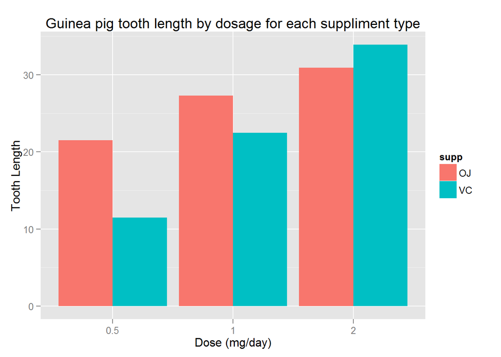

From above barplot, it seems to me that the amount dosage is positively correlated with tooth length. The suppliment also has different impace on the tooth length, orange juice is more effective than ascorbic acid for tooth growth. However, as the dosage increased to 2 mg, the impact is not obvious.

## Confidence Interval and and Hypothesis test

### Hypothesis 1

Different suppliments deliver the same tooth growth

```r
hy1 <- t.test(len ~ supp, data=ToothGrowth)
hy1$conf.int
```

```
## [1] -0.1710156  7.5710156
## attr(,"conf.level")
## [1] 0.95
```

```r
hy1$p.value
```

```
## [1] 0.06063451
```

The range of the tooth length data is between 4.2 and 33.9, which means there are observations in the dataset fall into the confidence interval (-0.1710, 7.5710), the P value is 0.0606, greater than 0.05. With this test results, we failed to reject the null hypothesis.

### Hypothesis 2

Differnt doseages deliver the same tooth growth

```r
# subset data by dose to create three groups for pairwise t test
dose1 <- subset(ToothGrowth, dose %in% c(0.5, 1.0))
dose2 <- subset(ToothGrowth, dose %in% c(1.0, 2.0))
dose3 <- subset(ToothGrowth, dose %in% c(0.5, 2.0))
t.test(len~dose, dose1, paired = F, var.equal=F)
```

```
##
##  Welch Two Sample t-test
##
## data:  len by dose
## t = -6.4766, df = 37.986, p-value = 1.268e-07
## alternative hypothesis: true difference in means is not equal to 0
## 95 percent confidence interval:
##  -11.983781  -6.276219
## sample estimates:
## mean in group 0.5   mean in group 1
##            10.605            19.735
```

```r
t.test(len~dose, dose2, paired=F, var.equal=F)
```

```
##
##  Welch Two Sample t-test
##
## data:  len by dose
## t = -4.9005, df = 37.101, p-value = 1.906e-05
## alternative hypothesis: true difference in means is not equal to 0
## 95 percent confidence interval:
##  -8.996481 -3.733519
## sample estimates:
## mean in group 1 mean in group 2
##          19.735          26.100
```

```r
t.test(len~dose, dose3, paired=F, var.equal=F)
```

```
##
##  Welch Two Sample t-test
##
## data:  len by dose
## t = -11.799, df = 36.883, p-value = 4.398e-14
## alternative hypothesis: true difference in means is not equal to 0
## 95 percent confidence interval:
##  -18.15617 -12.83383
## sample estimates:
## mean in group 0.5   mean in group 2
##            10.605            26.100
```

By examing the testing results, the P values for three tests are much lower than 0.05 and the confidence intervals ([-11.98, -6.27] for dose 0.5 and 1, [-8.996, -3.733] for dose 1 and 2, [-18.16, -12.83] for dose 0.5 and 2) are all in the negative area, which allows us to reject the null hypothesis that giving differnt doseages has not impact on tooth growth. Both confidence intervals, P values and t statistics give evidence of strong positive correlation between dosage and tooth growth.

### Hypothesis 3

Using different suppliment makes no difference within the same dose level

```r
dose5 <- subset(ToothGrowth, dose == 0.5)
dose10 <- subset(ToothGrowth, dose == 1.0)
dose20 <- subset(ToothGrowth, dose == 2.0)
t.test(len~supp, dose5, paired=F, val.equal=F)
```

```
##
##  Welch Two Sample t-test
##
## data:  len by supp
## t = 3.1697, df = 14.969, p-value = 0.006359
## alternative hypothesis: true difference in means is not equal to 0
## 95 percent confidence interval:
##  1.719057 8.780943
## sample estimates:
## mean in group OJ mean in group VC
##            13.23             7.98
```

```r
t.test(len~supp, dose10, paired=F, val.equal=F)
```

```
##
##  Welch Two Sample t-test
##
## data:  len by supp
## t = 4.0328, df = 15.358, p-value = 0.001038
## alternative hypothesis: true difference in means is not equal to 0
## 95 percent confidence interval:
##  2.802148 9.057852
## sample estimates:
## mean in group OJ mean in group VC
##            22.70            16.77
```

```r
t.test(len~supp, dose20, paired=F, val.equal=F)
```

```
##
##  Welch Two Sample t-test
##
## data:  len by supp
## t = -0.046136, df = 14.04, p-value = 0.9639
## alternative hypothesis: true difference in means is not equal to 0
## 95 percent confidence interval:
##  -3.79807  3.63807
## sample estimates:
## mean in group OJ mean in group VC
##            26.06            26.14
```

The test results shows that When given 0.5mg per day, using different suppliment makes big diffence growth. With the confidence interval of [1.72, 8.78] and p-value much smaller than 0.05, we can reject the null hypothesis.

When given 1.0mg per day, using different suppliment makes different in tooth growth. With the confidence interval of [2.80, 9.06] and p-value much smaller than 0.05, we can reject the null hypothesis.

When given 2.0mg per day, the test confidence interval is [-3.798, 3.638] and the p-value is 0.96, which is large than 0.05. With this test result, we failed to reject the null hypothsis. The evidence given by the test results tells us that that when given 2.0mg per day, using different suppliment dose not make difference.

### Conclusion and Assumption

In order to make draw the conclusion from the test we performed, we must assume: 1. The observations are independent. In this case, it means that the guinea pigs need to be used so each combination of dose level and delivery method were not affected by the other methods. 2. The dependent variable (Tooth Growth) has a normal distribution.

Given the preceding assumptions, we can infer that given guinea pigs different dosages will have different impact on their tooth growth no matter what delivery method is used. We are unable to infer that using different method will make difference in tooth growth in general. However, We can infer that when given smaller amount of dose (0.5mg, 1.0mg), the orange juice is more effective. When given 2.0mg, there is no sufficient evidence to suggest that one delivery method is more effective over the other.